# Дополнительный проект (ANOVA)

# 1 Описание данных

Данные представляют собой наблюдения, собранные 20 различными врачами. Они включают в себя следующие переменные:

**X** — порядковый номер пациента

**id** — уникальный идентификатор пациента

**drug_type** — тип принимаемого препарата

**is_relapse** — наличие рецидива

**age** — возраст пациента

**gender** — пол пациента

**days_in_hospital** — кол-во дней проведённых в больничном стационаре

# 2 Подготовка данных

## 2.1 Чтение данных

Для чтения и объединения данных была создана пользовательская функция, принимающая в качестве аргументов путь до папки, содержащей файлы с данными, формат записи данных и разделитель колонок (в случае текстового формата).

```r
concatenate_data <- function(path, format, delim="") {
    format_parser_map <- c(read.csv, read.csv2, read.delim, read_xls, read_xlsx)
    names(format_parser_map) <- c("csv-,", "csv-;", "tsv-", "xls-", "xlsx-")
    data_format <- paste(format, delim, sep="-")
    accumulated_data <- tibble()
    for (filename in list.files(path = path)) {
        new_data <- format_parser_map[[data_format]](paste(path, filename, sep="/"))
        accumulated_data = rbind(accumulated_data, new_data)

    }
    return(accumulated_data)
}
```

## 2.2 Коррекция и фильтрация данных

Для удобной работы с данными нужно привести их в соответствие с концепцией tidy-data.

Изначальная структура данных выглядит следующим образом:

```
## 'data.frame':    200 obs. of  7 variables:
##  $ X               : int  1 2 3 4 5 6 7 8 9 10 ...
##  $ gender          : chr  "female" "female" "female" "female" ...
##  $ age             : chr  "26" "26" "31" "28" ...
##  $ drug_type       : chr  "Placebo" "Placebo" "Placebo" "Placebo" ...
##  $ is_relapse      : int  0 1 0 1 1 NA 0 1 1 0 ...
##  $ id              : int  101 102 103 104 105 106 107 108 109 110 ...
##  $ days_in_hospital: num  25.2 23.3 29.9 27.8 23.3 ...
```

Для быстрой визуализации ошибок записи данных выведем уникальные значения каждой переменной.

```
## $X
##   [1]   1   2   3   4   5   6   7   8   9  10  91  92  93  94  95  96  97  98
##  [19]  99 100 101 102 103 104 105 106 107 108 109 110 111 112 113 114 115 116
##  [37] 117 118 119 120 121 122 123 124 125 126 127 128 129 130 131 132 133 134
##  [55] 135 136 137 138 139 140 141 142 143 144 145 146 147 148 149 150 151 152
##  [73] 153 154 155 156 157 158 159 160 161 162 163 164 165 166 167 168 169 170
##  [91] 171 172 173 174 175 176 177 178 179 180 181 182 183 184 185 186 187 188
## [109] 189 190  11  12  13  14  15  16  17  18  19  20 191 192 193 194 195 196
## [127] 197 198 199 200  21  22  23  24  25  26  27  28  29  30  31  32  33  34
## [145]  35  36  37  38  39  40  41  42  43  44  45  46  47  48  49  50  51  52
## [163]  53  54  55  56  57  58  59  60  61  62  63  64  65  66  67  68  69  70
## [181]  71  72  73  74  75  76  77  78  79  80  81  82  83  84  85  86  87  88
## [199]  89  90
##
## $gender
```

[output cut: 54 more lines]

Заметим, что переменные *X* и *id* несут одну и ту же информацию - уникальный идентификатор пациента, а значит можно удалить одну из них.

В ряде наблюдений присутствует опечатка “malle” вместо “male”, данные ошибки можно исправить.

В двух наблюдениях число 31 записано словами, данные значения можно заменить на числовые.

В двух наблюдениях наблюдаются невозможные значения переменной *age*: **350** и **220**. Вероятно, ошибка вызвана записью лишней цифры, однако однозначно восстановить число не представляется возможным, поэтому во избежание ложных результатов эти наблюдения можно убрать.

Переменные *gender*, *age*, *is_relapse* и *drug_type* представлены строковым типом, для дальнейшей работы нужно сделать их факторными.

Некоторые наблюдения имеют пропущенные значения переменной *is_relapse*, можно предположить, что осутствие данных о рецидиве свидетельствует о его фактическом отсутствии, однако пропущенных значений не слишком много и наблюдения, содержащие их, могут быть опущены.

После данных преобразований структура данных выглядит следующим образом:

```
## 'data.frame':    188 obs. of  6 variables:
##  $ gender          : Factor w/ 2 levels "female","male": 1 1 1 1 1 1 1 1 1 1 ...
##  $ age             : Factor w/ 15 levels "23","24","25",..: 4 4 9 6 7 14 9 9 8 14 ...
##  $ drug_type       : Factor w/ 4 levels "New_type_1","New_type_2",..: 4 4 4 4 4 4 4 4 4 2 ...
##  $ is_relapse      : Factor w/ 2 levels "0","1": 1 2 1 2 2 1 2 2 1 1 ...
##  $ id              : int  101 102 103 104 105 107 108 109 110 191 ...
##  $ days_in_hospital: num  25.2 23.3 29.9 27.8 23.3 ...
##  - attr(*, "na.action")= 'omit' Named int [1:10] 6 25 71 89 90 141 167 177 183 184
##   ..- attr(*, "names")= chr [1:10] "6" "25" "71" "89" ...
```

С ними уже можно работать дальше.

# 3 Предварительный анализ данных

Мы имеем всего одну непрерывную переменную в данных. Визуализируем её распределение для различных групп.

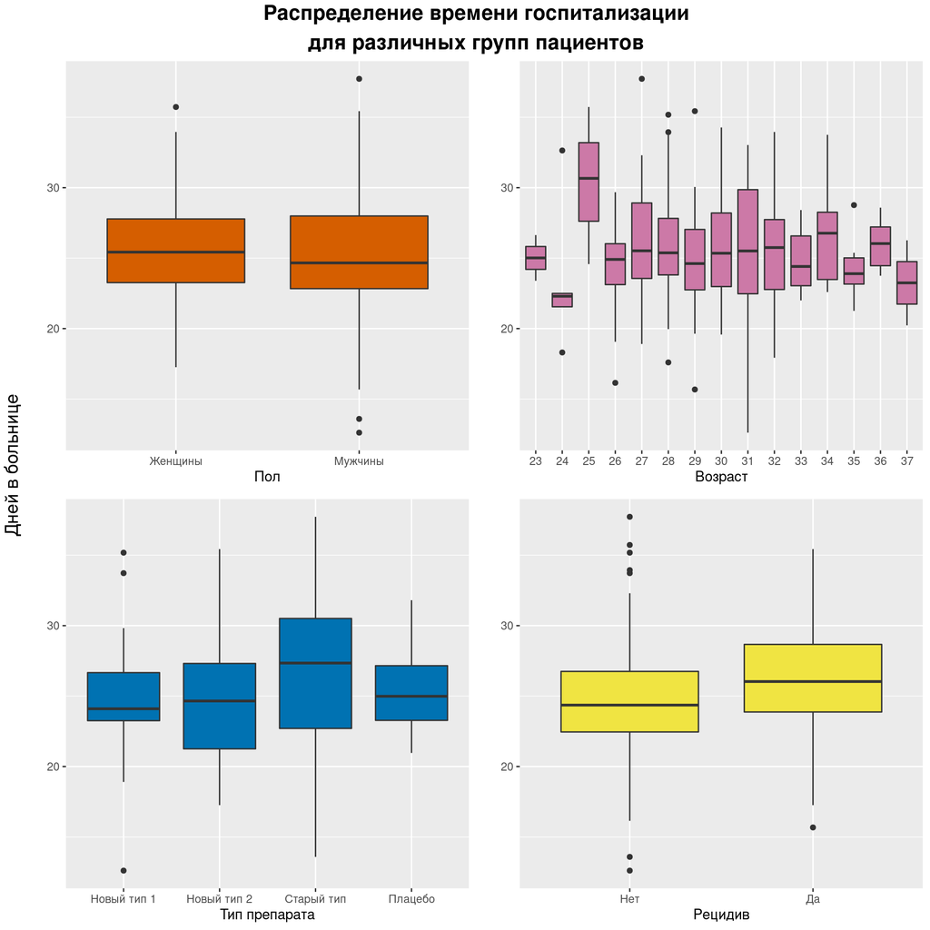

Заметим, что небольшие различия во времени госпитализации различаются среди пациентов, принимавших различные препараты, а также в группах по рецидиву.

Проверим распределение переменной *days_in_hospital* на нормальность.

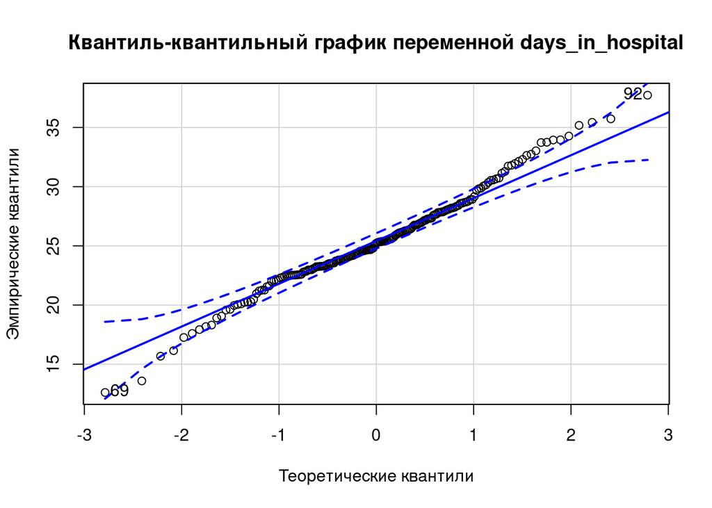

Квантиль-квантильный график выглядит не лучшим образом.

Проверим гипотезу о нормальном распределении переменной.

P-значение равно **0.064734**, а значит распределение переменной *days_in_hospital* значимо не отличается от нормального.

Поскольку дисперсионный анализ лучше работает с группами одинакового размера, проверим численность групп в наших данных.

| gender | drug_type | n |
| --- | --- | --- |
| Женщины | Новый тип 1 | 24 |
| Женщины | Новый тип 2 | 24 |
| Женщины | Старый тип | 22 |
| Женщины | Плацебо | 24 |
| Мужчины | Новый тип 1 | 24 |
| Мужчины | Новый тип 2 | 25 |
| Мужчины | Старый тип | 21 |
| Мужчины | Плацебо | 24 |

|  | gender | n |
| --- | --- | --- |
| 1 | Женщины | 94 |
| 2 | Мужчины | 94 |

|  | drug_type | n |
| --- | --- | --- |
| 1 | Новый тип 1 | 48 |
| 2 | Новый тип 2 | 49 |
| 3 | Старый тип | 43 |
| 4 | Плацебо | 48 |

Как видно из таблиц, группы имеют почти одинаковый размер.

# 4 Дисперсионный анализ

## 4.1 Построение модели

Сперва исследуем влияние факторов пола и типа препарата, а также их взаимодействия на время госпитализации при помощи двухфакторного дисперсионного анализа со взаимодействием.

|  | Sum Sq | Df | F value | Pr(>F) |
| --- | --- | --- | --- | --- |
| gender | 0.2985027 | 1 | 0.02335948 | 8.786971e-01 |
| drug_type | 96.8498888 | 3 | 2.52634634 | 5.900640e-02 |
| gender:drug_type | 850.1247739 | 3 | 22.17565384 | 2.883980e-12 |
| Residuals | 2300.1570462 | 180 | NA | NA |

## 4.2 Условия применимости

Построим график расстояний Кука для оценки наличия влиятельных наблюдений.

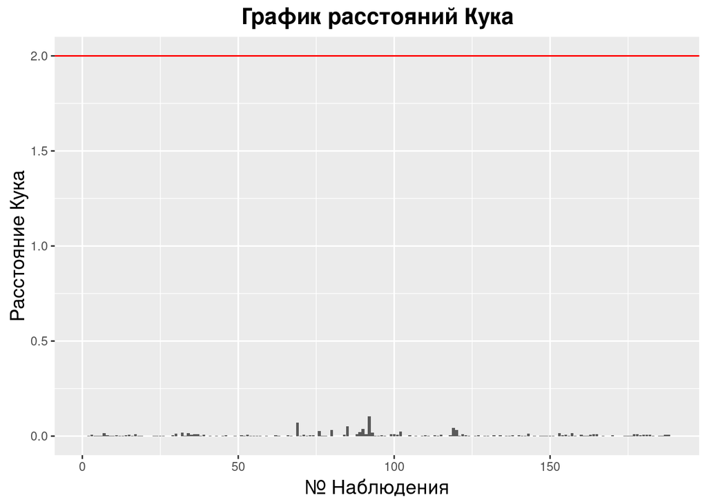

Из графика видно, что влиятельные наблюдения в данных отсутствуют.

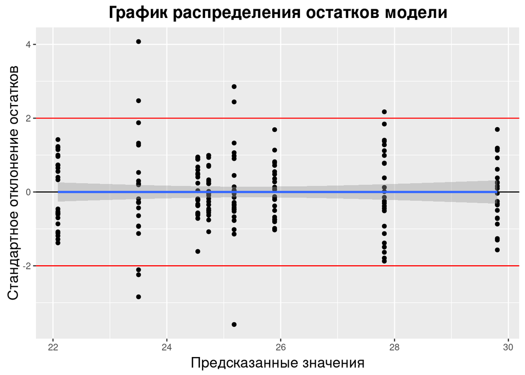

Из графика видно отсутствие паттернов в остатках, однако некоторые из них сильно отклоняются от 0.

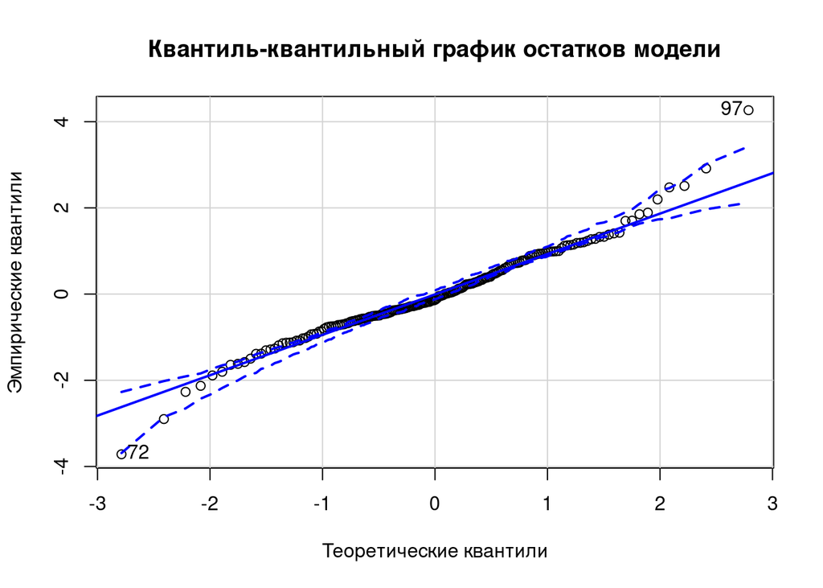

```
##
##  Shapiro-Wilk normality test
##
## data:  mod_diag$.resid
## W = 0.97829, p-value = 0.005047
```

Из квантиль-квантильного графика можно сделать вывод, что распределение близко к нормальному, но тест Шапиро-Уилка отвергает данную гипотезу.

## 4.3 Интерпретация результатов

В итоге мы имеем следующие результаты дисперсионного анализа.

|  | Sum Sq | Df | F value | Pr(>F) |
| --- | --- | --- | --- | --- |
| gender | 0.2985027 | 1 | 0.02335948 | 8.786971e-01 |
| drug_type | 96.8498888 | 3 | 2.52634634 | 5.900640e-02 |
| gender:drug_type | 850.1247739 | 3 | 22.17565384 | 2.883980e-12 |
| Residuals | 2300.1570462 | 180 | NA | NA |

Таким образом **cочетание типа принимаемого препарата и пола пациента значимо влияет на время госпитализации (F =22.1756538 , p_value = 2.8839805^{-12}, df_1 = 3, df_2 = 180)**.

Однако данные результаты не позволяют нам узнать сочетание каких уровней факторов влияет на время госпитализации. Для того, чтобы это выяснить необходимо провести пост-хок тесты.

Для этого подберём линейную модель без свободного члена, где в качестве предиктора выступает фактор взаимодействия.

Сначала создадим данный фактор, сгруппировав имеющиеся.

```r
hospital_data$Combined_features <- factor(paste(hospital_data$drug_type, hospital_data$gender, sep="-"))
```

Подберём модель:

```r
ph_model <- lm(days_in_hospital ~ Combined_features - 1, data = hospital_data)
```

Проведём пост-хок тест Тьюки на основе данной модели.

```r
post_hoch <- glht(ph_model, linfct = mcp(Combined_features = "Tukey"))
summary(post_hoch)
```

```
##
##   Simultaneous Tests for General Linear Hypotheses
##
## Multiple Comparisons of Means: Tukey Contrasts
##
##
## Fit: lm(formula = days_in_hospital ~ Combined_features - 1, data = hospital_data)
##
## Linear Hypotheses:
##                                            Estimate Std. Error t value Pr(>|t|)
## New_type_1-male - New_type_1-female == 0     0.6383     1.0319   0.619  0.99859
## New_type_2-female - New_type_1-female == 0  -2.4570     1.0319  -2.381  0.25676
## New_type_2-male - New_type_1-female == 0     3.2772     1.0216   3.208  0.03346
## Old_type-female - New_type_1-female == 0     5.2620     1.0551   4.987  < 0.001
## Old_type-male - New_type_1-female == 0      -1.0407     1.0682  -0.974  0.97749
## Placebo-female - New_type_1-female == 0      1.3499     1.0319   1.308  0.89470
## Placebo-male - New_type_1-female == 0        0.1914     1.0319   0.186  1.00000
## New_type_2-female - New_type_1-male == 0    -3.0953     1.0319  -3.000  0.06028
## New_type_2-male - New_type_1-male == 0       2.6389     1.0216   2.583  0.16889
## Old_type-female - New_type_1-male == 0       4.6237     1.0551   4.382  < 0.001
## Old_type-male - New_type_1-male == 0        -1.6790     1.0682  -1.572  0.76634
## Placebo-female - New_type_1-male == 0        0.7117     1.0319   0.690  0.99718
## Placebo-male - New_type_1-male == 0         -0.4468     1.0319  -0.433  0.99987
## New_type_2-male - New_type_2-female == 0     5.7342     1.0216   5.613  < 0.001
## Old_type-female - New_type_2-female == 0     7.7190     1.0551   7.316  < 0.001
## Old_type-male - New_type_2-female == 0       1.4163     1.0682   1.326  0.88788
## Placebo-female - New_type_2-female == 0      3.8070     1.0319   3.689  0.00705
## Placebo-male - New_type_2-female == 0        2.6485     1.0319   2.567  0.17538
## Old_type-female - New_type_2-male == 0       1.9848     1.0450   1.899  0.55307
## Old_type-male - New_type_2-male == 0        -4.3179     1.0581  -4.081  0.00169
## Placebo-female - New_type_2-male == 0       -1.9272     1.0216  -1.887  0.56145
## Placebo-male - New_type_2-male == 0         -3.0857     1.0216  -3.021  0.05698
## Old_type-male - Old_type-female == 0        -6.3027     1.0906  -5.779  < 0.001
## Placebo-female - Old_type-female == 0       -3.9120     1.0551  -3.708  0.00654
## Placebo-male - Old_type-female == 0         -5.0705     1.0551  -4.806  < 0.001
## Placebo-female - Old_type-male == 0          2.3906     1.0682   2.238  0.33411
## Placebo-male - Old_type-male == 0            1.2321     1.0682   1.154  0.94362
## Placebo-male - Placebo-female == 0          -1.1585     1.0319  -1.123  0.95108
##
## New_type_1-male - New_type_1-female == 0
```

[output cut: 15 more lines]

```
## Placebo-female - New_type_2-female == 0    **
## Placebo-male - New_type_2-female == 0
## Old_type-female - New_type_2-male == 0
## Old_type-male - New_type_2-male == 0       **
## Placebo-female - New_type_2-male == 0
## Placebo-male - New_type_2-male == 0        .
## Old_type-male - Old_type-female == 0       ***
## Placebo-female - Old_type-female == 0      **
## Placebo-male - Old_type-female == 0        ***
## Placebo-female - Old_type-male == 0
## Placebo-male - Old_type-male == 0
## Placebo-male - Placebo-female == 0
## ---
## Signif. codes:  0 '***' 0.001 '**' 0.01 '*' 0.05 '.' 0.1 ' ' 1
## (Adjusted p values reported -- single-step method)
```

Можно проинтерпретировать результаты следующим образом:

**Препарат 2 типа замедляет лечение и мужчин, но ускоряет лечение у женщин. Препарат старого типа замедляет лечение у женщин, но не оказывает значимого эффекта у мужчин**

Данные результаты также могут быть проиллюстрированы следующим графиком.

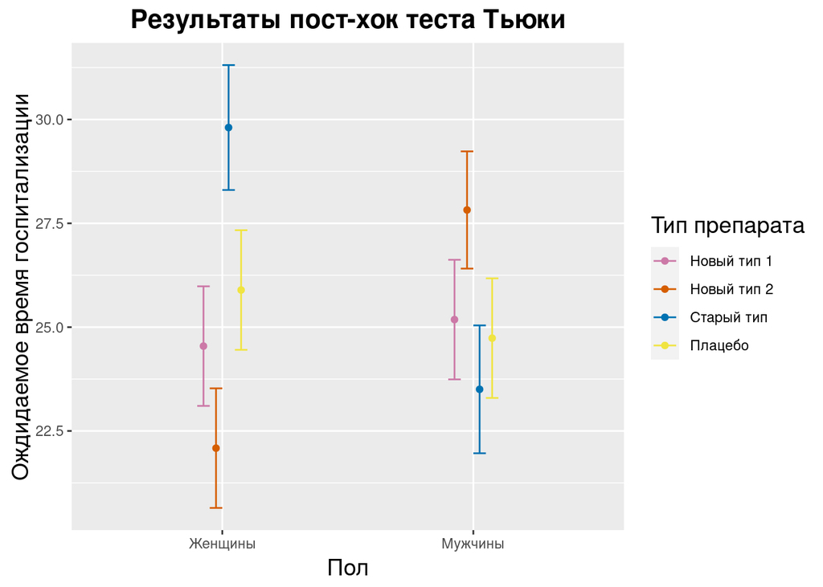